# Foundations of Data Mining: Assignment 1

## Nepalese character recognition (5 points, 1+2+2)

The [Devnagari-Script dataset](https://www.openml.org/d/40923) contains 92,000 images (32x32 pixels) of 46 characters from Devanagari script. Your goal is to learn to recognize the right letter given the image.

```python
devnagari = oml.datasets.get_dataset(40923) # Download Devnagari data
# Get the predictors X and the labels y
X, y = devnagari.get_data(target=devnagari.default_target_attribute);
classes = devnagari.retrieve_class_labels(target_name='character') # This one takes a while, skip if not needed
```

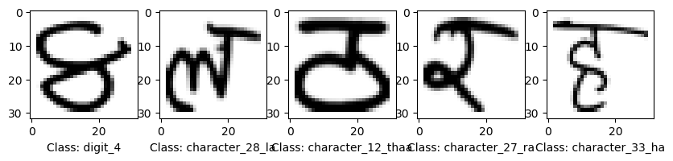

```python
from random import randint
# Take some random examples, reshape to a 32x32 image and plot
fig, axes = plt.subplots(1, 5,  figsize=(10, 5))
for i in range(5):
    n = randint(0,90000)
    axes[i].imshow(X[n].reshape(32, 32), cmap=plt.cm.gray_r)
    axes[i].set_xlabel("Class: %s" % (classes[y[n]]))
plt.show();
```

1. Evaluate k-Nearest Neighbors, Logistic Regression and RandomForests with their default settings.
   - Take a stratified 10% subsample of the data.
   - Use the default train-test split and predictive accuracy. Is predictive accuracy a good scoring measure for this problem?
   - Try to build the same models on increasingly large samples of the dataset (e.g. 10%, 20%,...). Plot the training time and the predictive performance for each. Stop when the training time becomes prohibitively large (this will be different for different models).

```python
from sklearn.neighbors import KNeighborsClassifier
from sklearn.model_selection import train_test_split
import time;

l = [0.5, 1, 1.5, 2, 2.5, 3, 3.5, 4, 4.5, 5]

knn_scores = []
knn_time = []

for z in l:
    X_train, X_test, y_train, y_test = train_test_split(X, y, stratify=y, test_size = ((z/10)*0.25), train_size = ((z/10)*0.75))

    # kNN
    start_time = time.time()
    clf = KNeighborsClassifier(n_jobs=-1).fit(X_train, y_train)
    knn_scores.append("%.2f" % float(format(clf.score(X_test, y_test))))
    end_time = time.time()

    knn_time.append((end_time-start_time))
```

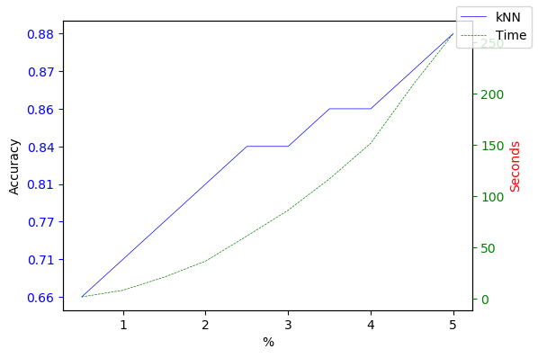

```python
# Plot
fig, ax1 = plt.subplots()

ax1.plot(l, knn_scores, label = "kNN", color='b')
ax1.set_xlabel("%")
ax1.set_ylabel("Accuracy")
ax1.tick_params('y', colors='b')

ax2 = ax1.twinx()
ax2.plot(l, knn_time, label = "Time", color='g', linestyle='--')
ax2.set_ylabel('Seconds', color='r')
ax2.tick_params('y', colors='g')

fig.tight_layout()
fig.legend()
plt.show()
```

```python
from sklearn.linear_model import LogisticRegression
from sklearn.model_selection import train_test_split
import time;

m = [0.4, 0.6, 0.8, 1, 1.2, 1.4, 1.6]

lr_scores = []
lr_time = []

for z in m:
    X_train, X_test, y_train, y_test = train_test_split(X, y, stratify=y, test_size = ((z/10)*0.25), train_size = ((z/10)*0.75))

    # Logistic Regression
    start_time = time.time()
    lr = LogisticRegression(n_jobs=-1).fit(X_train, y_train)
    lr_scores.append("%.2f" % float(format(lr.score(X_test, y_test))))
    end_time = time.time()

    lr_time.append((end_time-start_time))
```

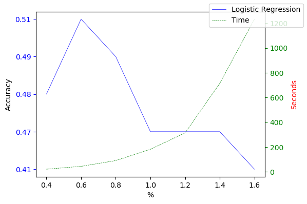

```python
# Plot
fig, ax1 = plt.subplots()

ax1.plot(m, lr_scores, label = "Logistic Regression", color='b')
ax1.set_xlabel("%")
ax1.set_ylabel("Accuracy")
ax1.tick_params('y', colors='b')

ax2 = ax1.twinx()
ax2.plot(m, lr_time, label = "Time", color='g', linestyle='--')
ax2.set_ylabel('Seconds', color='r')
ax2.tick_params('y', colors='g')

fig.tight_layout()
fig.legend()
plt.show()
```

```python
from sklearn.ensemble import RandomForestClassifier
from sklearn.model_selection import train_test_split
import time;

n = [1, 2, 3, 4, 5, 6, 7, 8, 9, 10]

rf_scores = []
rf_time = []

for z in n:
    X_train, X_test, y_train, y_test = train_test_split(X, y, stratify=y, test_size = ((z/10)*0.25), train_size = ((z/10)*0.75))

    # RandomForests
    start_time = time.time()
    forest = RandomForestClassifier(n_jobs=-1).fit(X_train, y_train)
    rf_scores.append("%.2f" % float(format(forest.score(X_test, y_test))))
    end_time = time.time()

    rf_time.append((end_time-start_time))
```

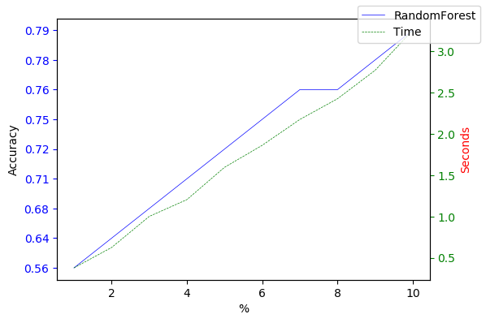

```python
# Plot
fig, ax1 = plt.subplots()

ax1.plot(n, rf_scores, label = "RandomForest", color='b')
ax1.set_xlabel("%")
ax1.set_ylabel("Accuracy")
ax1.tick_params('y', colors='b')

ax2 = ax1.twinx()
ax2.plot(n, rf_time, label = "Time", color='g', linestyle='--')
ax2.set_ylabel('Seconds', color='r')
ax2.tick_params('y', colors='g')

fig.tight_layout()
fig.legend()
plt.show()
```

Since recognition of any letter is equally important and there is no complicated cost function involved, we believe that predictive accuracy is a good scoring measure.

When choosing the right algorithm for the task (with default settings) we would choose kNN. It gave us the highest accuracy on only 50% of the data. The RandomForest algorithm was the fastest one of the three, but the accuracy was not as good as with the kNN. This can be prescribed to the fact that by default RF uses only 10 estimators. For better result we would have to increase the number of n_estimators. Logistic Regression performed the worst out of all three algorithms and we notice that the score does not depend strongly on the size of the sample used. Based on its performance and its high running times, it is safe to say that the Logistic Regression algorithm is not the best algorithm for this task.

2 . Optimize the value for the number of neighbors $k$ (keep $k$ < 50) and the number of trees (keep $n\_estimators$ < 100) on the stratified 10% subsample.

- Use 10-fold crossvalidation and plot $k$ and $n\_estimators$ against the predictive accuracy. Which value of $k$, $n\_estimators$ should you pick?

```python
from sklearn.model_selection import train_test_split
from sklearn.model_selection import cross_val_score

# Stratified x% subsample of the data
subsample = 0.1

X_train, X_test, y_train, y_test = train_test_split(X, y, stratify=y, test_size = (subsample*0.25), train_size = (subsample*0.75))
```

```python
# Optimal n_estiator
cvn_scores = []
i = range(1,101)

for n in i:
    forest = RandomForestClassifier(n_jobs=-1, n_estimators = n)
    scores = cross_val_score(forest, X_train, y_train, cv=10, scoring='accuracy', n_jobs=-1)
    cvn_scores.append(scores.mean())

MSEn = [1 - x for x in cvn_scores]

optimal_n = i[MSEn.index(min(MSEn))]
print("The optimal number of n_estimators ", optimal_n)
```

```
The optimal number of n_estimators  98
```

```python
# Optimal k
cvk_scores = []
j = range(1,51)

for k in j:
    knn = KNeighborsClassifier(n_jobs=-1, n_neighbors=k)
    scores = cross_val_score(knn, X_train, y_train, cv=10, scoring='accuracy', n_jobs=-1)
    cvk_scores.append(scores.mean())

MSEk = [1 - x for x in cvk_scores]

optimal_k = j[MSEk.index(min(MSEk))]
print("The optimal number of k neighbors is ", optimal_k)
```

```
The optimal number of k neighbors is  1
```

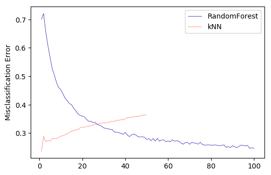

```
The optimal number of n_estimators: 98
The optimal number of k neighbors is: 1
```

```python
plt.plot(i, MSEn, label = 'RandomForest')
plt.plot(j, MSEk, label = 'kNN')
plt.legend()
plt.ylabel('Misclassification Error')
plt.show()

optimal_n = i[MSEn.index(min(MSEn))]
print("The optimal number of n_estimators:", optimal_n)

optimal_k = j[MSEk.index(min(MSEk))]
print("The optimal number of k neighbors is:", optimal_k)
```

We can observe that for the RandomForest classifier, it is best to choose as large as possible value of n_estimator. This produces more trees and creates smoother decision boundaries. However, the value of k in the kNN algorithm should stay relatively small. In our case the best value is 1. If we choose a large value for k, the model will be too simple and underfit the data.

3 . For the RandomForest, optimize both $n\_estimators$ and $max\_features$ at the same time on the entire dataset.

- Use a nested cross-validation and a random search over the possible values, and measure the accuracy. Explore how fine-grained this grid/random search can be, given your computational resources. What is the optimal performance you find?
- Hint: choose a nested cross-validation that is feasible. Don't use too many folds in the outer loop.
- Repeat the grid search and visualize the results as a plot (heatmap) $n\_estimators \times max\_features \rightarrow ACC$ with ACC visualized as the color of the data point. Try to make the grid as fine as possible. Interpret the results. Can you explain your observations? What did you learn about tuning RandomForests?

```python
from sklearn.model_selection import train_test_split
from sklearn.ensemble import RandomForestClassifier
from sklearn.model_selection import cross_val_score
from sklearn.model_selection import RandomizedSearchCV
from scipy.stats import expon

param_grid = {'n_estimators': [25, 50, 75, 100, 125, 150, 200],
               'max_features': [1, 5, 10, 20, 30, 50, 75, 100, 150]}

scores = cross_val_score(RandomizedSearchCV(RandomForestClassifier(n_jobs=-1), param_grid, n_iter=15, n_jobs=-1), X, y, cv=4, n_jobs=-1)
print("Cross-validation scores: ", scores)
print("Mean cross-validation score: ", scores.mean())
```

```
Cross-validation scores:  [ 0.695  0.751  0.729  0.726]
Mean cross-validation score:  0.725108695652
```

```python
from sklearn.model_selection import GridSearchCV
from sklearn.ensemble import RandomForestClassifier
from sklearn.model_selection import train_test_split

X_train, X_test, y_train, y_test = train_test_split(X, y, stratify=y, random_state=0)

param_grid = {'n_estimators': [25, 50, 75, 100, 125, 150, 200],
               'max_features': [1, 5, 10, 20, 30, 50, 75, 100, 150]}

grid_search = GridSearchCV(RandomForestClassifier(n_jobs=-1), param_grid, cv=4, n_jobs=-1)

grid_search.fit(X_train, y_train)

print("Best parameters: {}".format(grid_search.best_params_))
print("Best cross-validation score: {:.2f}".format(grid_search.best_score_))
```

```
Best parameters: {'max_features': 20, 'n_estimators': 200}
Best cross-validation score: 0.90
```

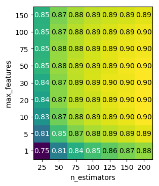

```python
import pandas as pd
# convert to Dataframe
results = pd.DataFrame(grid_search.cv_results_)
scores2 = np.array(results.mean_test_score).reshape(9, 7)
# plot the mean cross-validation scores
mglearn.tools.heatmap(scores2, xlabel='n_estimators', xticklabels=param_grid['n_estimators'],
                      ylabel='max_features', yticklabels=param_grid['max_features'], cmap="viridis");
```

With grid search we were able to determin the best values for max_features and n_estimators. For the RandomForest classifier, it is best to choose values as large as possible for n_estimators. This produces more trees and creates smoother decision boundaries. We believe that if we had more computational resources we could produce better results, with even bigger value of n_estimators.

## 3. Understanding Ensembles (5 points (3+2))

Do a deeper analysis of how RandomForests and Gradient Boosting reduce their prediction error. We'll use the MAGIC telescope dataset (http://www.openml.org/d/1120). When high-energy particles hit the atmosphere, they produce chain reactions of other particles called 'showers', and you need to detect whether these are caused by gamma rays or cosmic rays.

```python
# Get the data
magic_data = oml.datasets.get_dataset(1120) # Download MAGIC Telescope data
X, y = magic_data.get_data(target=magic_data.default_target_attribute);
```

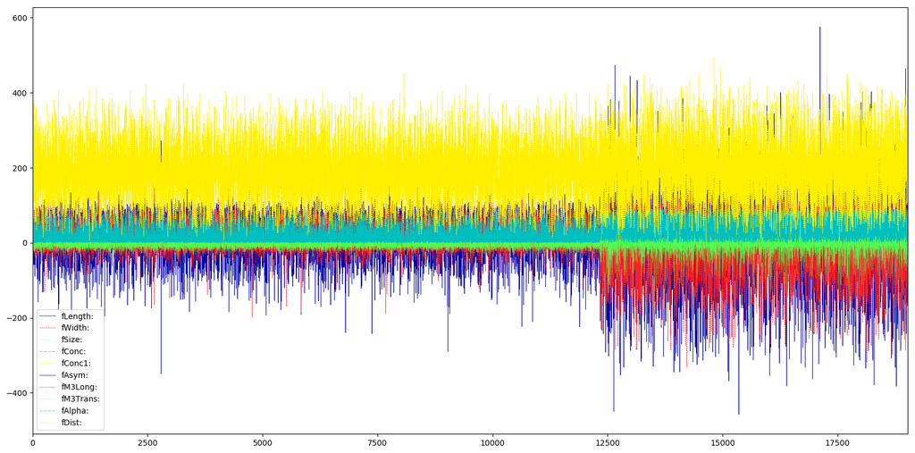

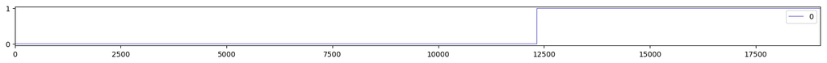

```python
# Quick visualization
X, y, attribute_names = magic_data.get_data(target=magic_data.default_target_attribute, return_attribute_names=True)
magic = pd.DataFrame(X, columns=attribute_names)
magic.plot(figsize=(20,10))
# Also plot the target: 1 = gamma, 0 = background
pd.DataFrame(y).plot(figsize=(20,1));
```

1 . Do a bias-variance analysis of both algorithms. For each, vary the number of trees on a log scale from 1 to 1024, and plot the bias error (squared), variance, and total error (in one plot per algorithm). Interpret the results. Which error is highest for small ensembles, and which reduced most by each algorithm as you use a larger ensemble? When are both algorithms under- or overfitting? Provide a detailed explanation of why random forests and gradient boosting behave this way.

- See lecture 3 for an example on how to do the bias-variance decomposition
- To save time, you can use a 10% stratified subsample in your initial experiments, but show the plots for the full dataset in your report.

```python
#10% stratified subsample
from sklearn.model_selection import train_test_split
X_ignore, X_sample, y_ignore, y_sample = train_test_split(X, y, stratify=y, test_size=0.1)
```

```python
#Random Forest
from sklearn.model_selection import ShuffleSplit
from sklearn.ensemble import RandomForestClassifier

rf_metrics = {}
for n in np.logspace(0, 10, num=11, base=2).astype(int):

    rf = RandomForestClassifier(n_estimators=n, random_state=2)

    # Bootstraps
    n_repeat = 100
    shuffle_split = ShuffleSplit(test_size=0.33, n_splits=n_repeat)

    # Store sample predictions
    y_all_pred = [[] for _ in range(len(y))]

    # Train classifier on each bootstrap and score predictions
    for i, (train_index, test_index) in enumerate(shuffle_split.split(X)):
        # Train and predict
        rf.fit(X[train_index], y[train_index])
        y_pred = rf.predict(X[test_index])

        # Store predictions
        for i,index in enumerate(test_index):
            y_all_pred[index].append(y_pred[i])

    # Compute bias, variance, error
    bias_sq = sum([ (1 - x.count(y[i])/len(x))**2 * len(x)/n_repeat
                for i,x in enumerate(y_all_pred) if len(x)>0])
    var = sum([((1 - ((x.count(0)/len(x))**2 + (x.count(1)/len(x))**2))/2) * len(x)/n_repeat
               for i,x in enumerate(y_all_pred) if len(x)>0])
    error = sum([ (1 - x.count(y[i])/len(x)) * len(x)/n_repeat
                for i,x in enumerate(y_all_pred) if len(x)>0])

    rf_metrics[n] = {}
    rf_metrics[n]['bias'] = bias_sq
    rf_metrics[n]['var'] = var
    rf_metrics[n]['error'] = error

for n in rf_metrics:
    print("Metrics for %d trees -> Bias squared: %.2f, Variance: %.2f, Total error: %.2f" % (n, rf_metrics[n]['bias'], rf_metrics[n]['var'], rf_metrics[n]['error']))
```

```
vuoto at 13648 []
Metrics for 1 trees -> Bias squared: 629.70, Variance: 623.00, Total error: 1252.70
Metrics for 2 trees -> Bias squared: 720.35, Variance: 397.19, Total error: 1117.53
Metrics for 4 trees -> Bias squared: 644.05, Variance: 305.98, Total error: 950.03
Metrics for 8 trees -> Bias squared: 623.89, Variance: 228.14, Total error: 852.03
Metrics for 16 trees -> Bias squared: 636.81, Variance: 176.09, Total error: 812.90
Metrics for 32 trees -> Bias squared: 645.91, Variance: 135.79, Total error: 781.70
Metrics for 64 trees -> Bias squared: 649.08, Variance: 110.05, Total error: 759.13
Metrics for 128 trees -> Bias squared: 670.26, Variance: 96.54, Total error: 766.80
Metrics for 256 trees -> Bias squared: 673.21, Variance: 85.85, Total error: 759.07
Metrics for 512 trees -> Bias squared: 672.73, Variance: 79.20, Total error: 751.93
Metrics for 1024 trees -> Bias squared: 678.60, Variance: 77.77, Total error: 756.37
```

```python
#Gradient Boosting
from sklearn.model_selection import ShuffleSplit
from sklearn.ensemble import GradientBoostingClassifier

gb_metrics = {}
for n in np.logspace(0, 10, num=11, base=2).astype(int):

    gb = GradientBoostingClassifier(n_estimators=n, random_state=2)

    # Bootstraps
    n_repeat = 100
    shuffle_split = ShuffleSplit(test_size=0.33, n_splits=n_repeat)

    # Store sample predictions
    y_all_pred = [[] for _ in range(len(y))]

    # Train classifier on each bootstrap and score predictions
    for i, (train_index, test_index) in enumerate(shuffle_split.split(X)):
        # Train and predict
        gb.fit(X[train_index], y[train_index])
        y_pred = gb.predict(X[test_index])

        # Store predictions
        for i,index in enumerate(test_index):
            y_all_pred[index].append(y_pred[i])

    # Compute bias, variance, error
    bias_sq = sum([ (1 - x.count(y[i])/len(x))**2 * len(x)/n_repeat
                for i,x in enumerate(y_all_pred) if len(x)>0])
    var = sum([((1 - ((x.count(0)/len(x))**2 + (x.count(1)/len(x))**2))/2) * len(x)/n_repeat
               for i,x in enumerate(y_all_pred) if len(x)>0])
    error = sum([ (1 - x.count(y[i])/len(x)) * len(x)/n_repeat
                for i,x in enumerate(y_all_pred) if len(x)>0])

    gb_metrics[n] = {}
    gb_metrics[n]['bias'] = bias_sq
    gb_metrics[n]['var'] = var
    gb_metrics[n]['error'] = error

for n in gb_metrics:
     print("Metrics for %d trees -> Bias squared: %.2f, Variance: %.2f, Total error: %.2f" % (n, gb_metrics[n]['bias'], gb_metrics[n]['var'], gb_metrics[n]['error']))
```

```
vuoto at 8210 []
Metrics for 1 trees -> Bias squared: 2215.90, Variance: 0.00, Total error: 2215.90
Metrics for 2 trees -> Bias squared: 2197.93, Variance: 0.00, Total error: 2197.93
Metrics for 4 trees -> Bias squared: 1362.52, Variance: 57.78, Total error: 1420.30
Metrics for 8 trees -> Bias squared: 1199.91, Variance: 54.83, Total error: 1254.73
Metrics for 16 trees -> Bias squared: 969.41, Variance: 71.22, Total error: 1040.63
Metrics for 32 trees -> Bias squared: 855.96, Variance: 69.70, Total error: 925.67
Metrics for 64 trees -> Bias squared: 770.52, Variance: 63.68, Total error: 834.20
Metrics for 128 trees -> Bias squared: 721.21, Variance: 73.26, Total error: 794.47
Metrics for 256 trees -> Bias squared: 681.85, Variance: 89.85, Total error: 771.70
Metrics for 512 trees -> Bias squared: 644.53, Variance: 103.97, Total error: 748.50
Metrics for 1024 trees -> Bias squared: 619.28, Variance: 125.76, Total error: 745.03
```

```python
#Save metrics to file as dataframes

#Random Forest
rf_df = pd.DataFrame(columns=['bias','var','error'])
for n in rf_metrics:
    rf_df.loc[n] = [rf_metrics[n]['bias'], rf_metrics[n]['var'], rf_metrics[n]['error']]

rf_df.to_csv("randomforest_metrics.csv")

#Gradient Boosting
gb_df = pd.DataFrame(columns=['bias','var','error'])
for n in gb_metrics:
    gb_df.loc[n] = [gb_metrics[n]['bias'], gb_metrics[n]['var'], gb_metrics[n]['error']]

gb_df.to_csv("gradientboosting_metrics.csv")
```

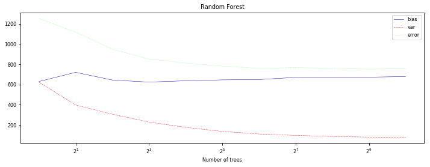

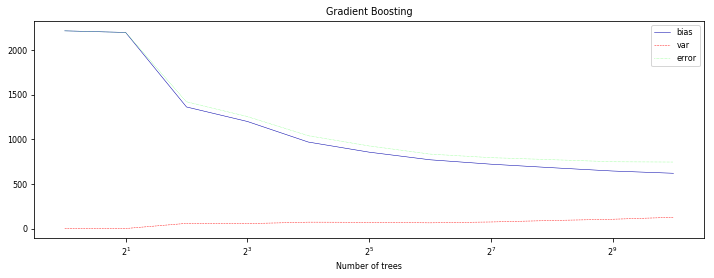

```python
#Load metrics from files and plot

#Random Forest
rf_df = pd.read_csv("randomforest_metrics.csv", index_col=0)
ax = rf_df.plot(figsize=(12,4), logx=True)
ax.set_xscale('log', basex=2)
plt.title('Random Forest')
plt.xlabel('Number of trees')
plt.legend(loc='best');

#Gradient Boosting
gb_df = pd.read_csv("gradientboosting_metrics.csv", index_col=0)
ax = gb_df.plot(figsize=(12,4), logx=True)
ax.set_xscale('log', basex=2)
plt.title('Gradient Boosting')
plt.xlabel('Number of trees')
plt.legend(loc='best');
```

The first difference that we can observe in the two graphs is that Random Forest has a notably higher variance, which then decreases with for higher numbers of trees, while Gradient Boosting has a variance that is almost null in the beginning and tends to increase. The general error in the beginning is much higher in the Gradient Boost model, but with the increasing of the number of trees it tends towards the same value (~800) for both models.

Let us first analyze the two cases separately. In Random Forest, when starting out with a single estimator, the bias and the variance values are equivalent. The bias grows slighly for two estimators, but then remains quite stable throughout the graph. Variance, on the other hand, steadily decreases when using a higher number of estimators, tending towards zero. This behavior is cause by an initial overfitting of the model, which is then gradually corrected.

In Gradient Boosting, contrarily, variance is quite steady, and it even increases slightly with higher numbers of estimators, while bias is improves throughout the graph. In fact, the plot shows a very high bias value for a single estimators, then the value decreases strongly for 4 estimators and it continues to decrease gradually. This is justified by an underfitting of the model.

Generally, both models benefit from a high number of estimateros: with around 128 estimators, they perform with very similiar error values. The reasons for this improvement is specular in the two models: in Random Forest the initial model is too complex, and it overfits the training data, while in Gradient Boosting the model is initially too simple and not enough flexible, underfitting the data. We should also note that while one of the two metrics is improoving the other gets worse, resulting in the risk to either underfit (in Random Forset) or overfit (in Gradient Boosting) the model, for excessively high numbers of estimators.

2 . A *validation curve* can help you understand when a model starts under- or overfitting. It plots both training and test set error as you change certain characteristics of your model, e.g. one or more hyperparameters. Build validation curves for gradient boosting, evaluated using AUROC, by varying the number of iterations between 1 and 500. In addition, use at least two values for the learning rate (e.g. 0.1 and 1), and tree depth (e.g. 1 and 4). This will yield at least 4 curves. Interpret the results and provide a clear explanation for the results. When is the model over- or underfitting? Discuss the effect of the different combinations learning rate and tree depth and provide a clear explanation.

- While scikit-learn has a `validation_curve` function, we'll use a modified version (below) that provides a lot more detail and can be used to study more than one hyperparameter. You can use a default train-test split.

```python
# Plots validation curves for every classifier in clfs.
# Also indicates the optimal result by a vertical line
# Uses 1-AUROC, so lower is better
from sklearn.metrics import roc_auc_score

def validation_curve(clfs, X_test, y_test, X_train, y_train):
    plt.figure(figsize=(13,6))
    for n,clf in enumerate(clfs):
        test_score = np.empty(len(clf.estimators_))
        train_score = np.empty(len(clf.estimators_))

        for i, pred in enumerate(clf.staged_decision_function(X_test)):
            test_score[i] = 1-roc_auc_score(y_test, pred)

        for i, pred in enumerate(clf.staged_decision_function(X_train)):
            train_score[i] = 1-roc_auc_score(y_train, pred)

        best_iter = np.argmin(test_score)
        learn = clf.get_params()['learning_rate']
        depth = clf.get_params()['max_depth']
        test_line = plt.plot(test_score, '-',
                             label='learn=%.1f depth=%i (%.2f)'%(learn,depth,
                                                                 test_score[best_iter]))

        colour = test_line[-1].get_color()
        plt.plot(train_score, '--', color=colour)

        plt.xlabel("Number of boosting iterations")
        plt.ylabel("1 - area under ROC")
        plt.axvline(x=best_iter, color=colour)

    plt.legend(loc='best')
```

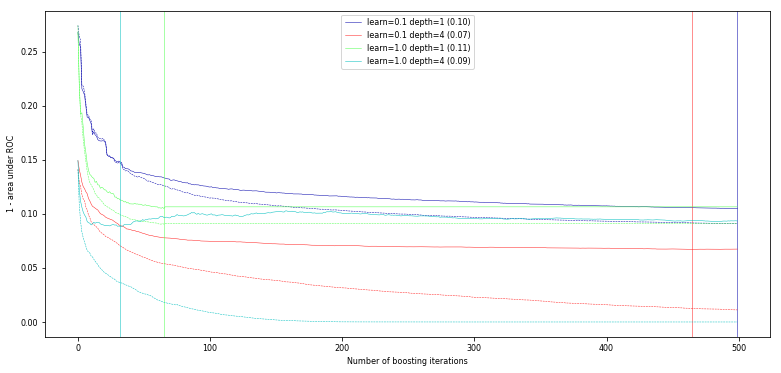

```python
from sklearn.ensemble import GradientBoostingClassifier
X_train, X_test, y_train, y_test = train_test_split(X, y, stratify=y)

clfs = [
    GradientBoostingClassifier(n_estimators=500, learning_rate=0.1, max_depth=1, random_state=2).fit(X_train, y_train),
    GradientBoostingClassifier(n_estimators=500, learning_rate=0.1, max_depth=4, random_state=2).fit(X_train, y_train),
    GradientBoostingClassifier(n_estimators=500, learning_rate=1.0, max_depth=1, random_state=2).fit(X_train, y_train),
    GradientBoostingClassifier(n_estimators=500, learning_rate=1.0, max_depth=4, random_state=2).fit(X_train, y_train)
]

validation_curve(clfs, X_test, y_test, X_train, y_train)
```

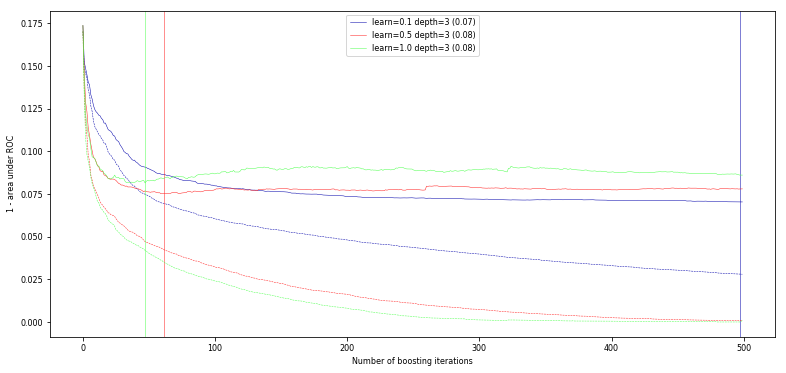

```python
clfs = [
    GradientBoostingClassifier(n_estimators=500, learning_rate=0.1, max_depth=3, random_state=2).fit(X_train, y_train),
    GradientBoostingClassifier(n_estimators=500, learning_rate=0.5, max_depth=3, random_state=2).fit(X_train, y_train),
    GradientBoostingClassifier(n_estimators=500, learning_rate=1.0, max_depth=3, random_state=2).fit(X_train, y_train)
]

validation_curve(clfs, X_test, y_test, X_train, y_train)
```

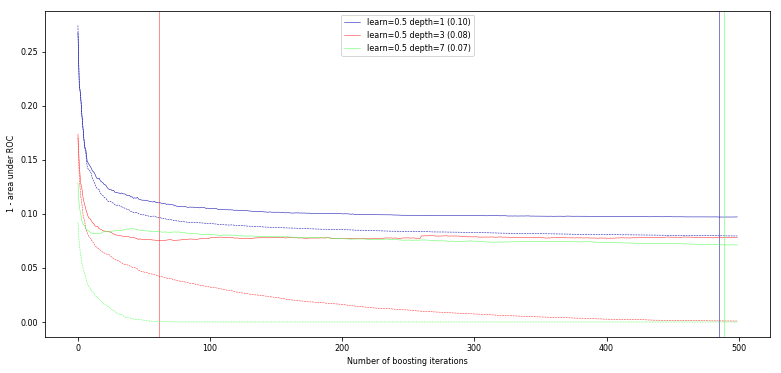

```python
clfs = [
    GradientBoostingClassifier(n_estimators=500, learning_rate=0.5, max_depth=1, random_state=2).fit(X_train, y_train),
    GradientBoostingClassifier(n_estimators=500, learning_rate=0.5, max_depth=3, random_state=2).fit(X_train, y_train),
    GradientBoostingClassifier(n_estimators=500, learning_rate=0.5, max_depth=7, random_state=2).fit(X_train, y_train)
]

validation_curve(clfs, X_test, y_test, X_train, y_train)
```

In the second plot we can observe the behavior of three model in which the max depth is stable at 3, while the learning rate varies from 0.1, to 0.5 to 1. We can see that while for low numbers of iteration a high rate results in better performance: starting from 50 iterations, the higher the learning rate and the more the model overfits. This is also emphasized by the great difference between test curves and train curves: the case of learning rate=1, for example, very rapidly starts to overfit and for a number of iterations of 70 or more it has the worst test performance out of the three cases.